# Codebook

```r
knitr::opts_chunk$set(
  warning = TRUE, # show warnings during codebook generation
  message = TRUE, # show messages during codebook generation
  error = TRUE, # do not interrupt codebook generation in case of errors,
                # usually better for debugging
  echo = TRUE  # show R code
)
ggplot2::theme_set(ggplot2::theme_bw())
```

Now, we’re preparing our data for the codebook.

```r
library(codebook)
UCI_HAR_dataset <- read.table("output.txt",header = TRUE)
# to import an SPSS file from the same folder uncomment and edit the line below
# codebook_data <- rio::import("mydata.sav")
# for Stata
# codebook_data <- rio::import("mydata.dta")
# for CSV
# codebook_data <- rio::import("mydata.csv")

# omit the following lines, if your missing values are already properly labelled
UCI_HAR_dataset <- detect_missing(UCI_HAR_dataset,
    only_labelled = TRUE, # only labelled values are autodetected as
                                   # missing
    negative_values_are_missing = FALSE, # negative values are missing values
    ninety_nine_problems = TRUE,   # 99/999 are missing values, if they
                                   # are more than 5 MAD from the median
    )

# If you are not using formr, the codebook package needs to guess which items
# form a scale. The following line finds item aggregates with names like this:
# scale = scale_1 + scale_2R + scale_3R
# identifying these aggregates allows the codebook function to
# automatically compute reliabilities.
# However, it will not reverse items automatically.
UCI_HAR_dataset <- detect_scales(codebook_data)
```

```
## Error in detect_scales(codebook_data): object 'codebook_data' not found
```

Create codebook

```r
codebook(UCI_HAR_dataset)
```

```
## No missing values.
```

### Metadata

#### Description

**Dataset name**: UCI_HAR_dataset

The dataset has N=180 rows and 88 columns. 180 rows have no missing values on any column.

**Metadata for search engines**

- **Date published**: 2020-09-18

| x |
| --- |
| activity |
| subjects |
| TimeBodyAccelerometer.mean…X |
| TimeBodyAccelerometer.mean…Y |
| TimeBodyAccelerometer.mean…Z |
| TimeGravityAccelerometer.mean…X |
| TimeGravityAccelerometer.mean…Y |
| TimeGravityAccelerometer.mean…Z |
| TimeBodyAccelerometerJerk.mean…X |
| TimeBodyAccelerometerJerk.mean…Y |
| TimeBodyAccelerometerJerk.mean…Z |
| TimeBodyGyroscope.mean…X |
| TimeBodyGyroscope.mean…Y |
| TimeBodyGyroscope.mean…Z |
| TimeBodyGyroscopeJerk.mean…X |
| TimeBodyGyroscopeJerk.mean…Y |
| TimeBodyGyroscopeJerk.mean…Z |
| TimeBodyAccelerometerMagnitude.mean.. |
| TimeGravityAccelerometerMagnitude.mean.. |
| TimeBodyAccelerometerJerkMagnitude.mean.. |
| TimeBodyGyroscopeMagnitude.mean.. |
| TimeBodyGyroscopeJerkMagnitude.mean.. |
| FrequencyBodyAccelerometer.mean…X |
| FrequencyBodyAccelerometer.mean…Y |
| FrequencyBodyAccelerometer.mean…Z |
| FrequencyBodyAccelerometer.meanFreq…X |
| FrequencyBodyAccelerometer.meanFreq…Y |
| FrequencyBodyAccelerometer.meanFreq…Z |
| FrequencyBodyAccelerometerJerk.mean…X |
| FrequencyBodyAccelerometerJerk.mean…Y |

[output cut: 58 more lines]

#Variables

### activity

#### Distribution

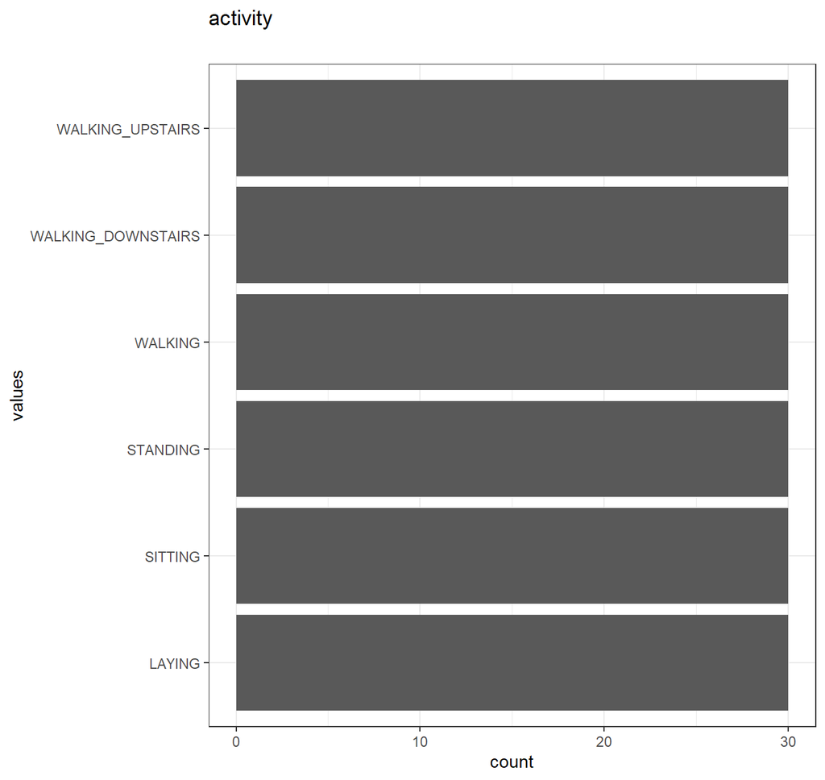

Distribution of values for activity

0 missing values.

#### Summary statistics

| name | data_type | n_missing | complete_rate | n_unique | empty | min | max | whitespace | label |
| --- | --- | --- | --- | --- | --- | --- | --- | --- | --- |
| activity | character | 0 | 1 | 6 | 0 | 6 | 18 | 0 | NA |

### subjects

#### Distribution

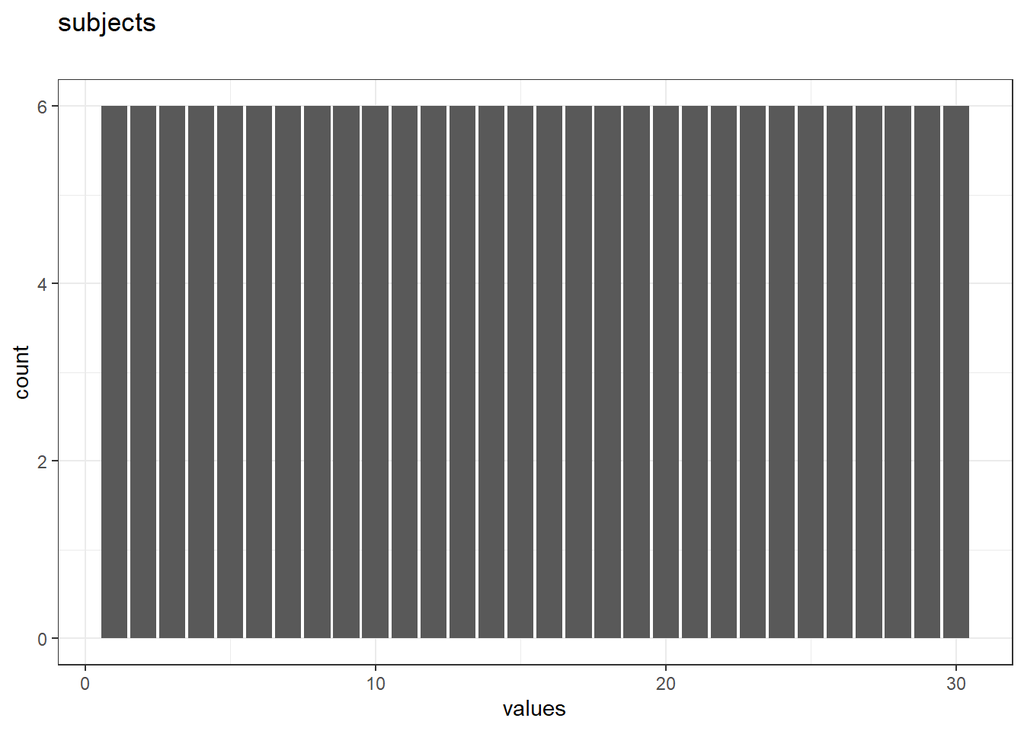

Distribution of values for subjects

0 missing values.

#### Summary statistics

| name | data_type | n_missing | complete_rate | min | median | max | mean | sd | hist | label |
| --- | --- | --- | --- | --- | --- | --- | --- | --- | --- | --- |
| subjects | numeric | 0 | 1 | 1 | 16 | 30 | 15.5 | 8.679585 | ▇▇▇▇▇ | NA |

### TimeBodyAccelerometer.mean…X

#### Distribution

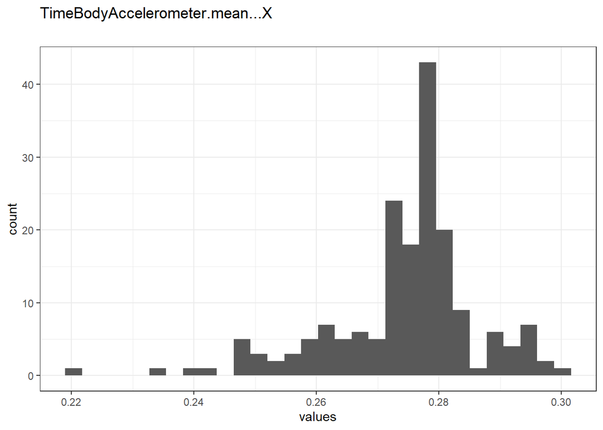

Distribution of values for TimeBodyAccelerometer.mean…X

0 missing values.

#### Summary statistics

| name | data_type | n_missing | complete_rate | min | median | max | mean | sd | hist | label |
| --- | --- | --- | --- | --- | --- | --- | --- | --- | --- | --- |
| TimeBodyAccelerometer.mean…X | numeric | 0 | 1 | 0.22 | 0.28 | 0.3 | 0.2743027 | 0.0121646 | ▁▁▂▇▂ | NA |

### TimeBodyAccelerometer.mean…Y

#### Distribution

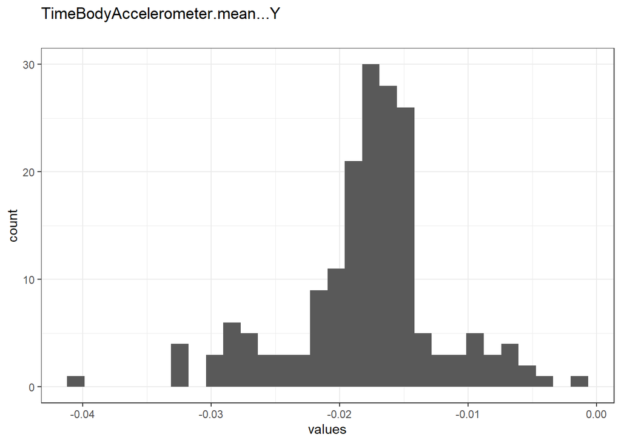

Distribution of values for TimeBodyAccelerometer.mean…Y

0 missing values.

#### Summary statistics

| name | data_type | n_missing | complete_rate | min | median | max | mean | sd | hist | label |
| --- | --- | --- | --- | --- | --- | --- | --- | --- | --- | --- |
| TimeBodyAccelerometer.mean…Y | numeric | 0 | 1 | -0.041 | -0.017 | -0.0013 | -0.0178755 | 0.0057712 | ▁▂▇▇▁ | NA |

### TimeBodyAccelerometer.mean…Z

#### Distribution

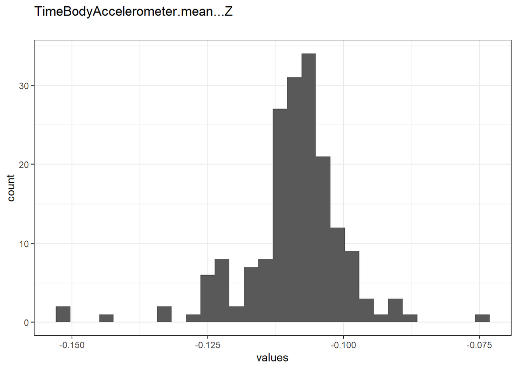

Distribution of values for TimeBodyAccelerometer.mean…Z

0 missing values.

#### Summary statistics

| name | data_type | n_missing | complete_rate | min | median | max | mean | sd | hist | label |
| --- | --- | --- | --- | --- | --- | --- | --- | --- | --- | --- |
| TimeBodyAccelerometer.mean…Z | numeric | 0 | 1 | -0.15 | -0.11 | -0.075 | -0.1091638 | 0.009582 | ▁▁▇▅▁ | NA |

### TimeGravityAccelerometer.mean…X

#### Distribution

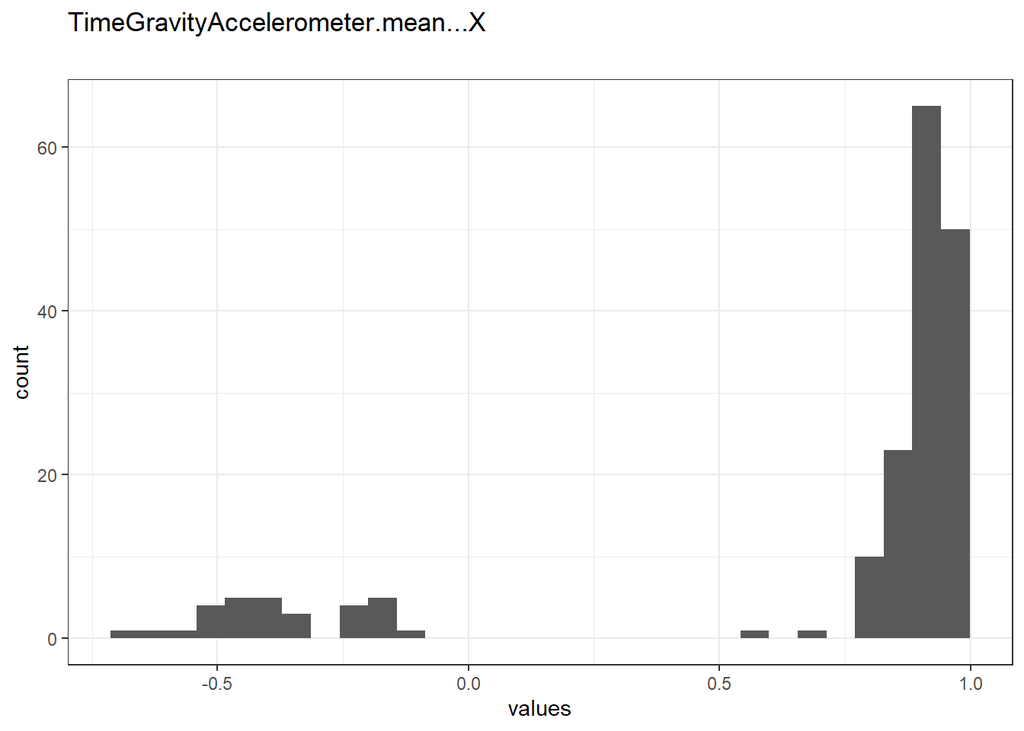

Distribution of values for TimeGravityAccelerometer.mean…X

0 missing values.

#### Summary statistics

| name | data_type | n_missing | complete_rate | min | median | max | mean | sd | hist | label |
| --- | --- | --- | --- | --- | --- | --- | --- | --- | --- | --- |
| TimeGravityAccelerometer.mean…X | numeric | 0 | 1 | -0.68 | 0.92 | 0.97 | 0.6974775 | 0.4872534 | ▁▁▁▁▇ | NA |

### TimeGravityAccelerometer.mean…Y

#### Distribution

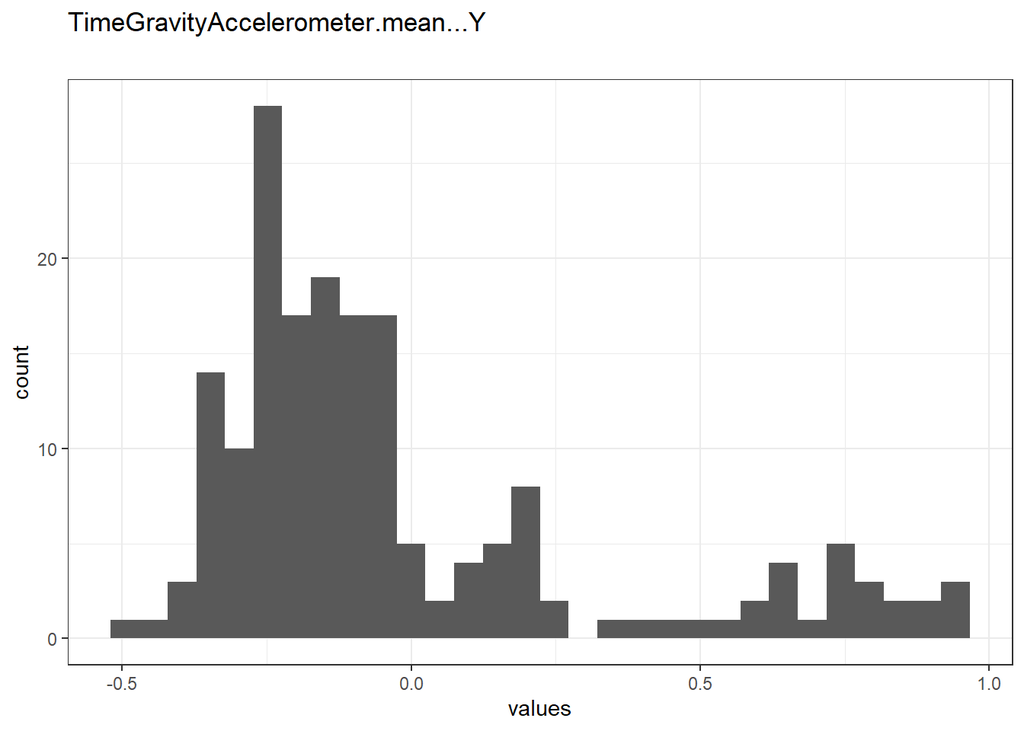

Distribution of values for TimeGravityAccelerometer.mean…Y

0 missing values.

#### Summary statistics

| name | data_type | n_missing | complete_rate | min | median | max | mean | sd | hist | label |
| --- | --- | --- | --- | --- | --- | --- | --- | --- | --- | --- |
| TimeGravityAccelerometer.mean…Y | numeric | 0 | 1 | -0.48 | -0.13 | 0.96 | -0.0162128 | 0.3452376 | ▇▇▂▁▂ | NA |

### TimeGravityAccelerometer.mean…Z

#### Distribution

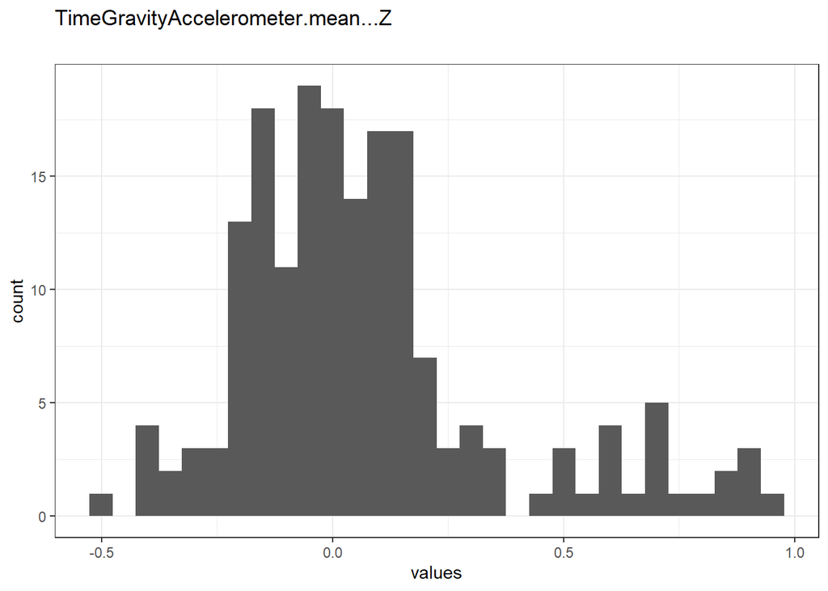

Distribution of values for TimeGravityAccelerometer.mean…Z

0 missing values.

#### Summary statistics

| name | data_type | n_missing | complete_rate | min | median | max | mean | sd | hist | label |
| --- | --- | --- | --- | --- | --- | --- | --- | --- | --- | --- |
| TimeGravityAccelerometer.mean…Z | numeric | 0 | 1 | -0.5 | 0.024 | 0.96 | 0.0741279 | 0.2887919 | ▂▇▃▁▁ | NA |

### TimeBodyAccelerometerJerk.mean…X

#### Distribution

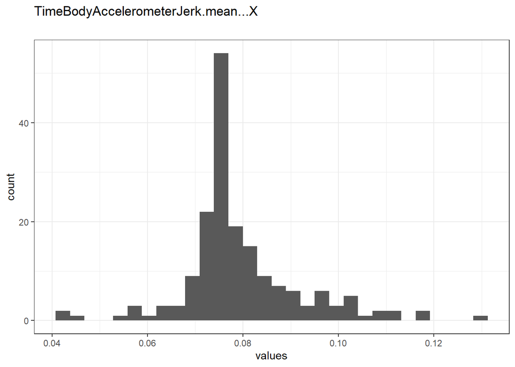

Distribution of values for TimeBodyAccelerometerJerk.mean…X

0 missing values.

#### Summary statistics

| name | data_type | n_missing | complete_rate | min | median | max | mean | sd | hist | label |
| --- | --- | --- | --- | --- | --- | --- | --- | --- | --- | --- |
| TimeBodyAccelerometerJerk.mean…X | numeric | 0 | 1 | 0.043 | 0.076 | 0.13 | 0.0794736 | 0.012588 | ▁▇▃▂▁ | NA |

### TimeBodyAccelerometerJerk.mean…Y

#### Distribution

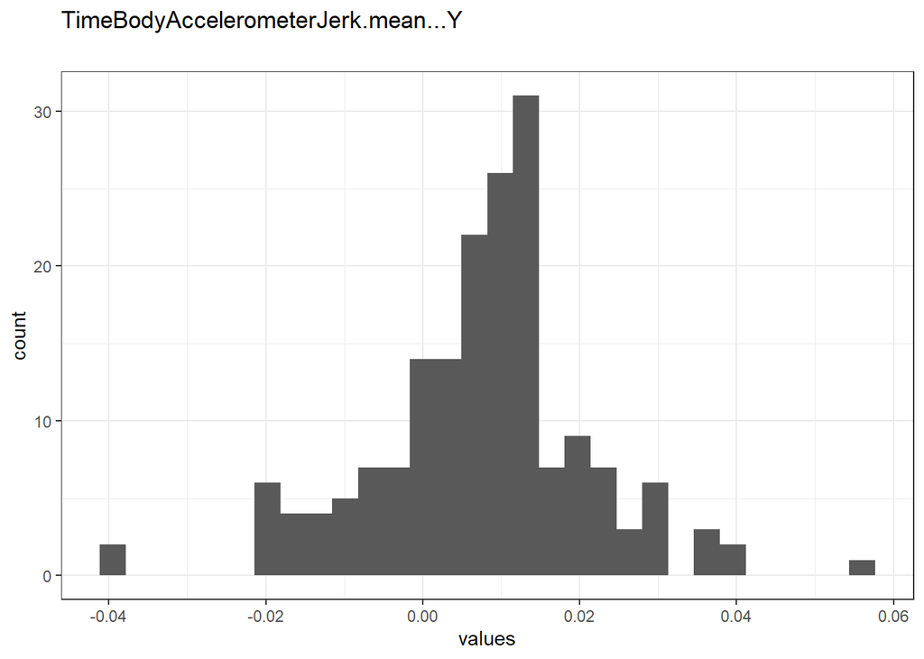

Distribution of values for TimeBodyAccelerometerJerk.mean…Y

0 missing values.

#### Summary statistics

| name | data_type | n_missing | complete_rate | min | median | max | mean | sd | hist | label |
| --- | --- | --- | --- | --- | --- | --- | --- | --- | --- | --- |
| TimeBodyAccelerometerJerk.mean…Y | numeric | 0 | 1 | -0.039 | 0.0095 | 0.057 | 0.0075652 | 0.0135764 | ▁▃▇▂▁ | NA |

### TimeBodyAccelerometerJerk.mean…Z

#### Distribution

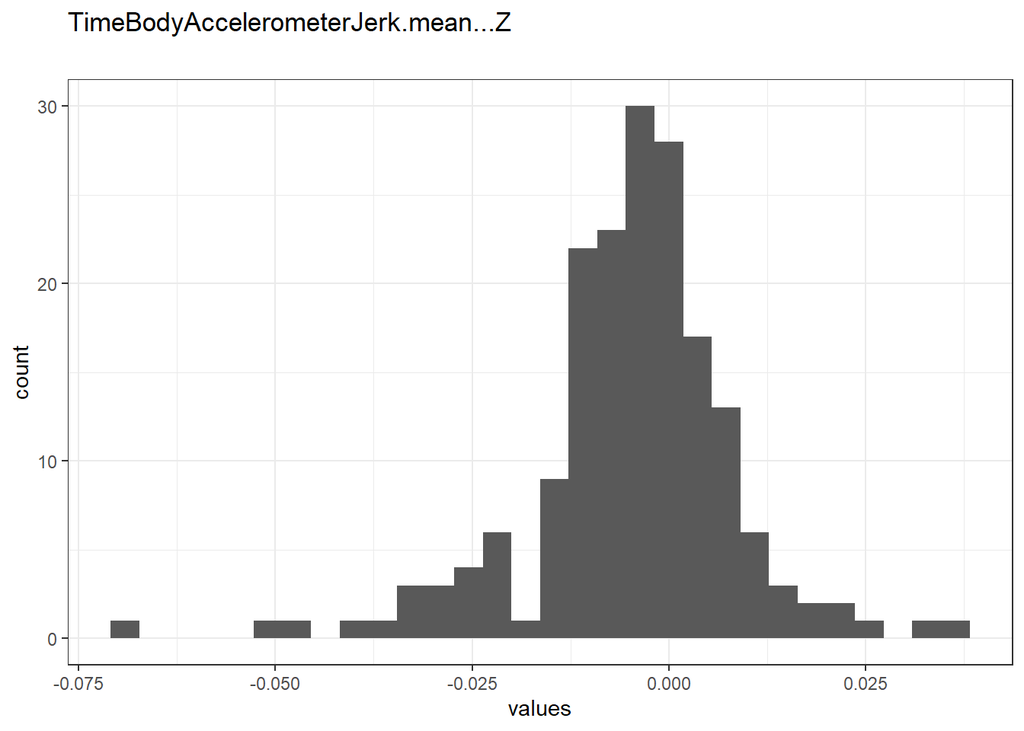

Distribution of values for TimeBodyAccelerometerJerk.mean…Z

0 missing values.

#### Summary statistics

| name | data_type | n_missing | complete_rate | min | median | max | mean | sd | hist | label |
| --- | --- | --- | --- | --- | --- | --- | --- | --- | --- | --- |
| TimeBodyAccelerometerJerk.mean…Z | numeric | 0 | 1 | -0.067 | -0.0039 | 0.038 | -0.0049534 | 0.0134621 | ▁▁▇▇▁ | NA |

### TimeBodyGyroscope.mean…X

#### Distribution

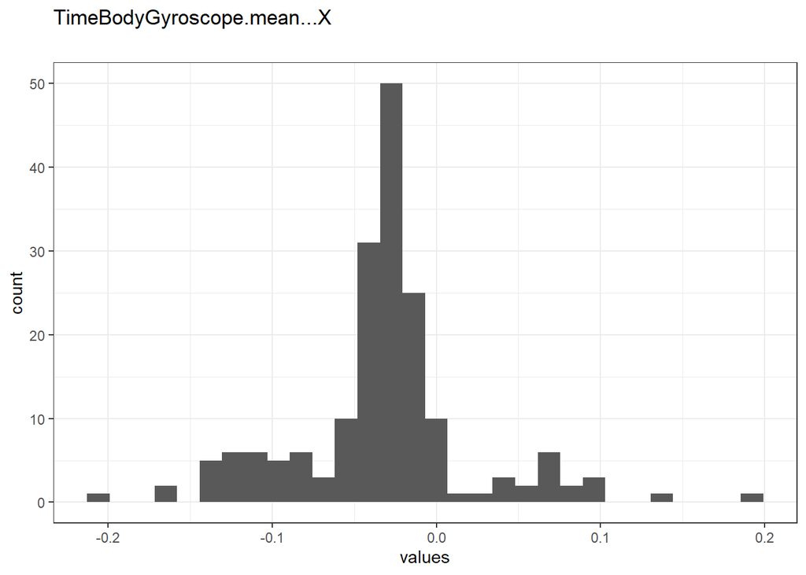

Distribution of values for TimeBodyGyroscope.mean…X

0 missing values.

#### Summary statistics

| name | data_type | n_missing | complete_rate | min | median | max | mean | sd | hist | label |
| --- | --- | --- | --- | --- | --- | --- | --- | --- | --- | --- |
| TimeBodyGyroscope.mean…X | numeric | 0 | 1 | -0.21 | -0.029 | 0.19 | -0.0324372 | 0.0540518 | ▁▂▇▁▁ | NA |

### TimeBodyGyroscope.mean…Y

#### Distribution

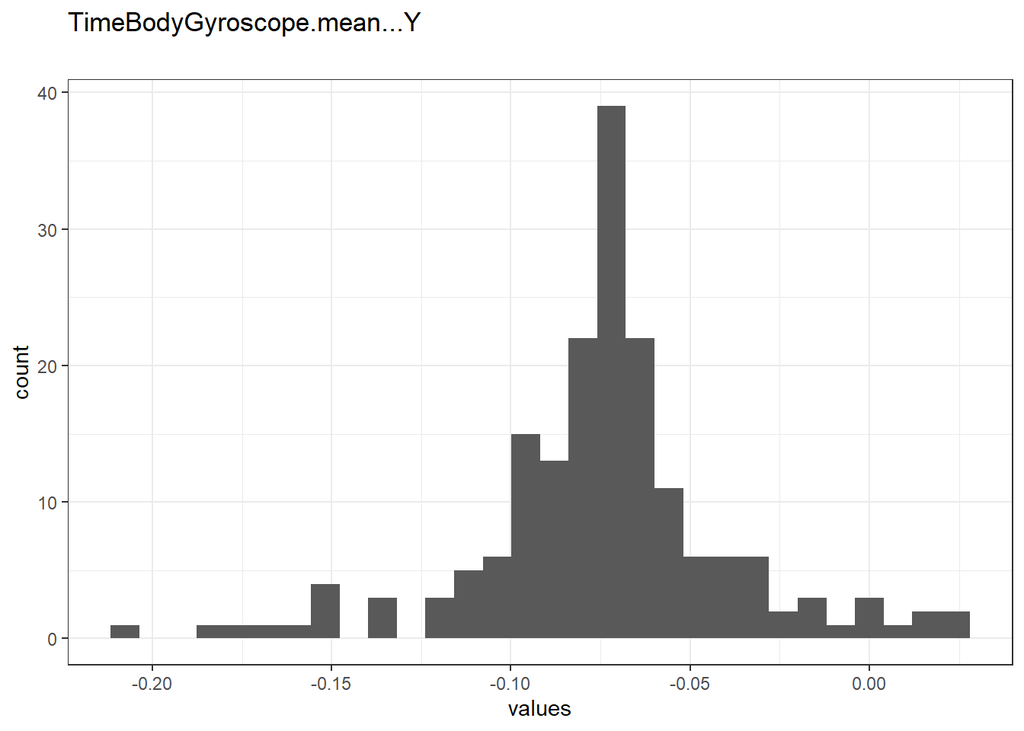

Distribution of values for TimeBodyGyroscope.mean…Y

0 missing values.

#### Summary statistics

| name | data_type | n_missing | complete_rate | min | median | max | mean | sd | hist | label |
| --- | --- | --- | --- | --- | --- | --- | --- | --- | --- | --- |
| TimeBodyGyroscope.mean…Y | numeric | 0 | 1 | -0.2 | -0.073 | 0.027 | -0.0742596 | 0.0355415 | ▁▁▇▃▁ | NA |

### TimeBodyGyroscope.mean…Z

#### Distribution

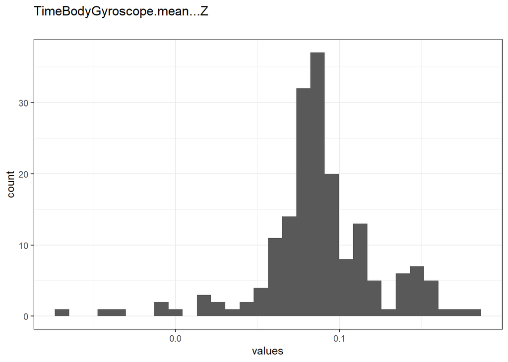

Distribution of values for TimeBodyGyroscope.mean…Z

0 missing values.

#### Summary statistics

| name | data_type | n_missing | complete_rate | min | median | max | mean | sd | hist | label |
| --- | --- | --- | --- | --- | --- | --- | --- | --- | --- | --- |
| TimeBodyGyroscope.mean…Z | numeric | 0 | 1 | -0.072 | 0.085 | 0.18 | 0.0874446 | 0.0362125 | ▁▁▃▇▂ | NA |

### TimeBodyGyroscopeJerk.mean…X

#### Distribution

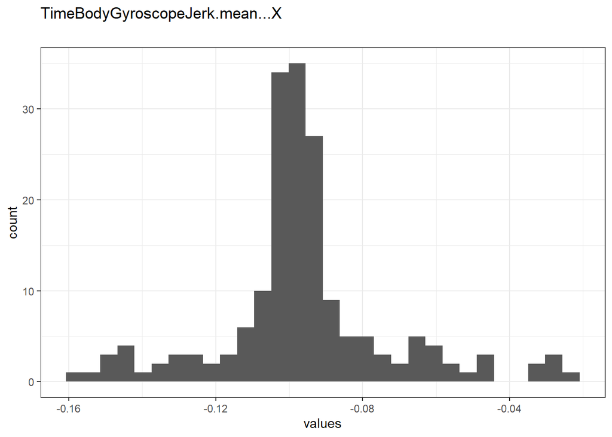

Distribution of values for TimeBodyGyroscopeJerk.mean…X

0 missing values.

#### Summary statistics

| name | data_type | n_missing | complete_rate | min | median | max | mean | sd | hist | label |
| --- | --- | --- | --- | --- | --- | --- | --- | --- | --- | --- |
| TimeBodyGyroscopeJerk.mean…X | numeric | 0 | 1 | -0.16 | -0.099 | -0.022 | -0.0960568 | 0.0233458 | ▁▂▇▁▁ | NA |

### TimeBodyGyroscopeJerk.mean…Y

#### Distribution

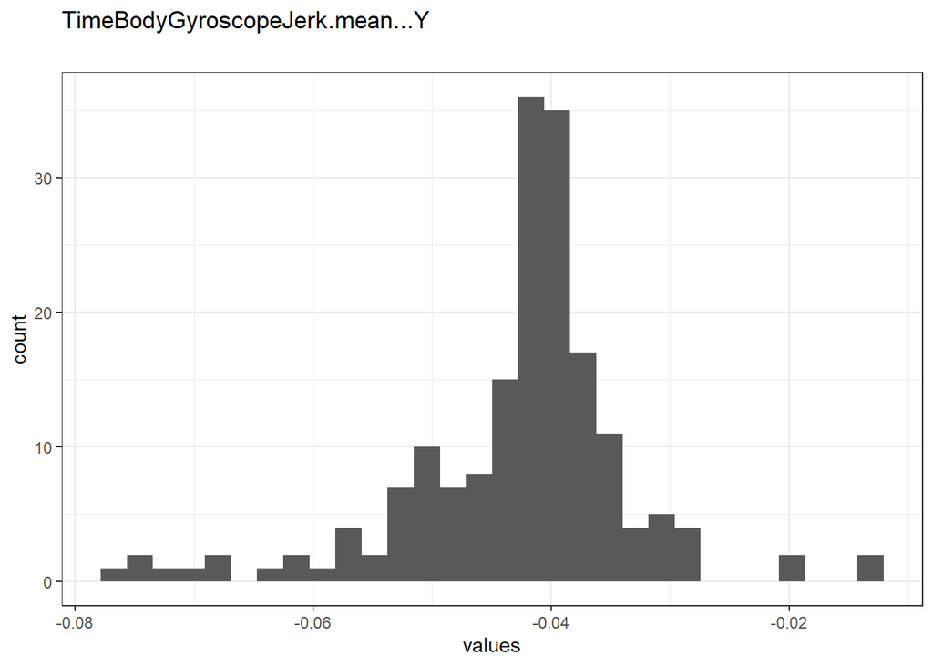

Distribution of values for TimeBodyGyroscopeJerk.mean…Y

0 missing values.

#### Summary statistics

| name | data_type | n_missing | complete_rate | min | median | max | mean | sd | hist | label |
| --- | --- | --- | --- | --- | --- | --- | --- | --- | --- | --- |
| TimeBodyGyroscopeJerk.mean…Y | numeric | 0 | 1 | -0.077 | -0.041 | -0.013 | -0.0426928 | 0.009532 | ▁▂▇▃▁ | NA |

### TimeBodyGyroscopeJerk.mean…Z

#### Distribution

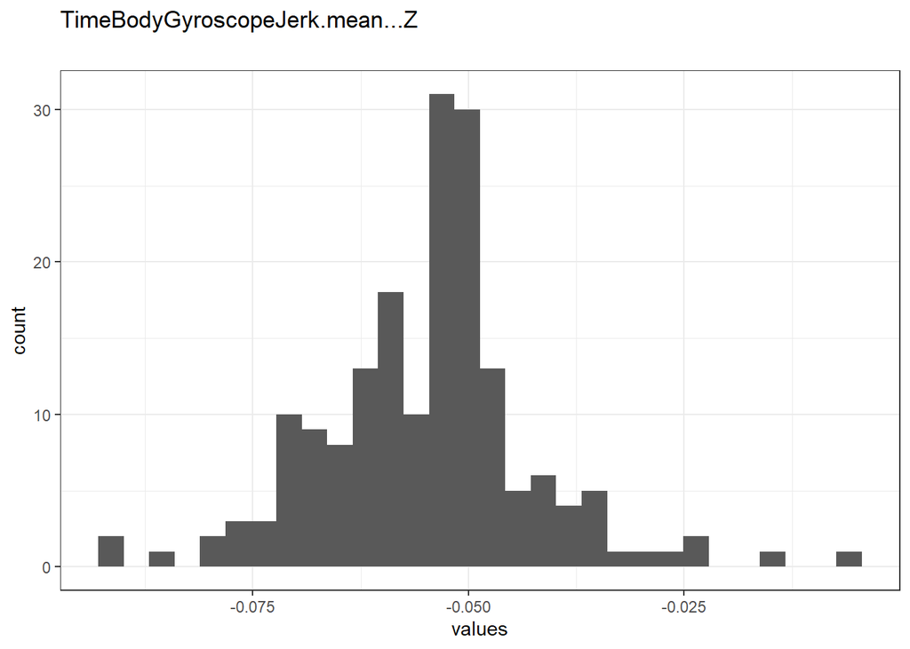

Distribution of values for TimeBodyGyroscopeJerk.mean…Z

0 missing values.

#### Summary statistics

| name | data_type | n_missing | complete_rate | min | median | max | mean | sd | hist | label |
| --- | --- | --- | --- | --- | --- | --- | --- | --- | --- | --- |
| TimeBodyGyroscopeJerk.mean…Z | numeric | 0 | 1 | -0.092 | -0.053 | -0.0069 | -0.0548019 | 0.012347 | ▁▅▇▁▁ | NA |

### TimeBodyAccelerometerMagnitude.mean..

#### Distribution

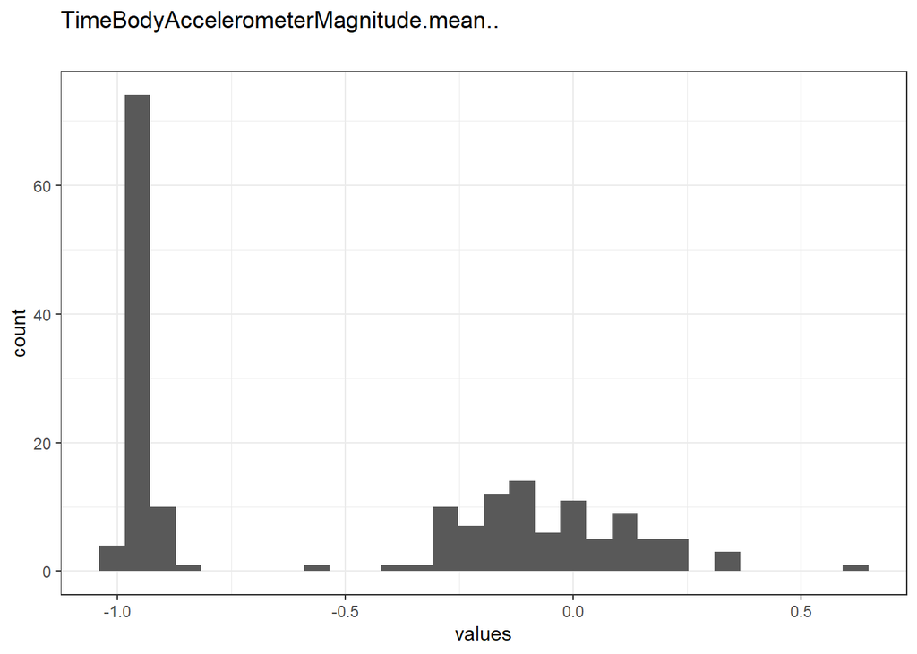

Distribution of values for TimeBodyAccelerometerMagnitude.mean..

0 missing values.

#### Summary statistics

| name | data_type | n_missing | complete_rate | min | median | max | mean | sd | hist | label |
| --- | --- | --- | --- | --- | --- | --- | --- | --- | --- | --- |
| TimeBodyAccelerometerMagnitude.mean.. | numeric | 0 | 1 | -0.99 | -0.48 | 0.64 | -0.4972897 | 0.4728834 | ▇▁▅▃▁ | NA |

### TimeGravityAccelerometerMagnitude.mean..

#### Distribution

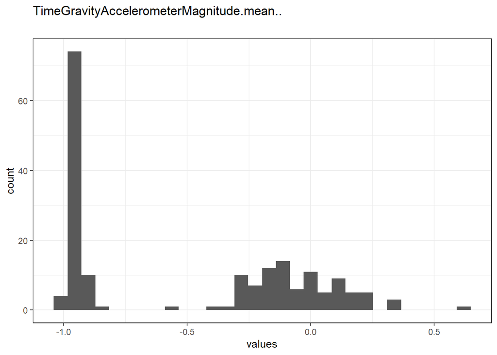

Distribution of values for TimeGravityAccelerometerMagnitude.mean..

0 missing values.

#### Summary statistics

| name | data_type | n_missing | complete_rate | min | median | max | mean | sd | hist | label |
| --- | --- | --- | --- | --- | --- | --- | --- | --- | --- | --- |
| TimeGravityAccelerometerMagnitude.mean.. | numeric | 0 | 1 | -0.99 | -0.48 | 0.64 | -0.4972897 | 0.4728834 | ▇▁▅▃▁ | NA |

### TimeBodyAccelerometerJerkMagnitude.mean..

#### Distribution

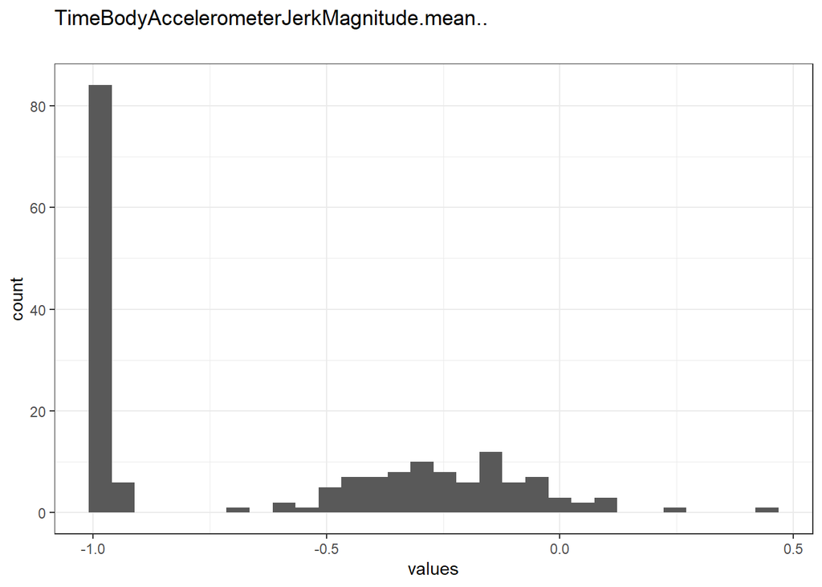

Distribution of values for TimeBodyAccelerometerJerkMagnitude.mean..

0 missing values.

#### Summary statistics

| name | data_type | n_missing | complete_rate | min | median | max | mean | sd | hist | label |
| --- | --- | --- | --- | --- | --- | --- | --- | --- | --- | --- |
| TimeBodyAccelerometerJerkMagnitude.mean.. | numeric | 0 | 1 | -0.99 | -0.82 | 0.43 | -0.6079296 | 0.3965272 | ▇▂▅▂▁ | NA |

### TimeBodyGyroscopeMagnitude.mean..

#### Distribution

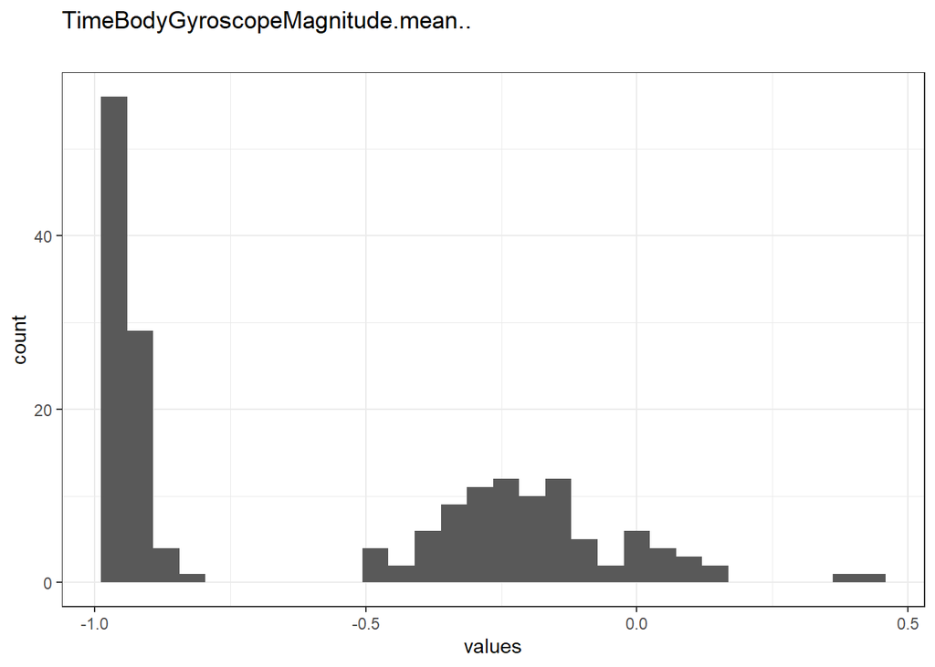

Distribution of values for TimeBodyGyroscopeMagnitude.mean..

0 missing values.

#### Summary statistics

| name | data_type | n_missing | complete_rate | min | median | max | mean | sd | hist | label |
| --- | --- | --- | --- | --- | --- | --- | --- | --- | --- | --- |
| TimeBodyGyroscopeMagnitude.mean.. | numeric | 0 | 1 | -0.98 | -0.66 | 0.42 | -0.5651631 | 0.3977338 | ▇▁▅▂▁ | NA |

### TimeBodyGyroscopeJerkMagnitude.mean..

#### Distribution

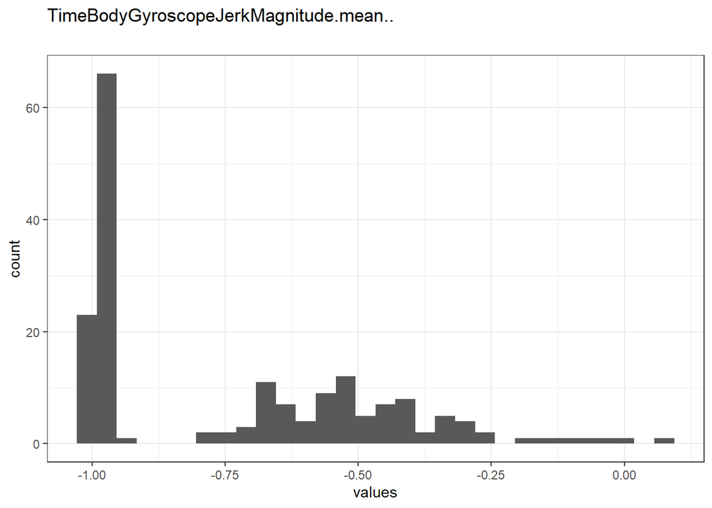

Distribution of values for TimeBodyGyroscopeJerkMagnitude.mean..

0 missing values.

#### Summary statistics

| name | data_type | n_missing | complete_rate | min | median | max | mean | sd | hist | label |
| --- | --- | --- | --- | --- | --- | --- | --- | --- | --- | --- |
| TimeBodyGyroscopeJerkMagnitude.mean.. | numeric | 0 | 1 | -1 | -0.86 | 0.088 | -0.7363693 | 0.2767541 | ▇▃▃▁▁ | NA |

### FrequencyBodyAccelerometer.mean…X

#### Distribution

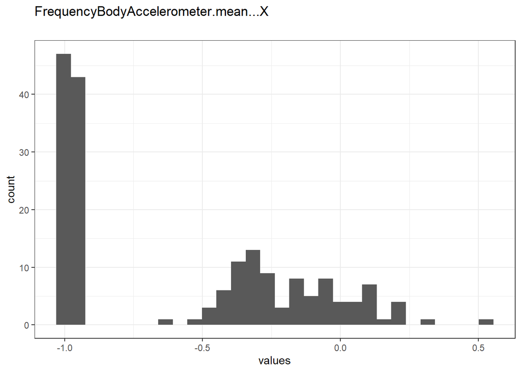

Distribution of values for FrequencyBodyAccelerometer.mean…X

0 missing values.

#### Summary statistics

| name | data_type | n_missing | complete_rate | min | median | max | mean | sd | hist | label |
| --- | --- | --- | --- | --- | --- | --- | --- | --- | --- | --- |
| FrequencyBodyAccelerometer.mean…X | numeric | 0 | 1 | -1 | -0.77 | 0.54 | -0.5758 | 0.4300214 | ▇▁▃▂▁ | NA |

### FrequencyBodyAccelerometer.mean…Y

#### Distribution

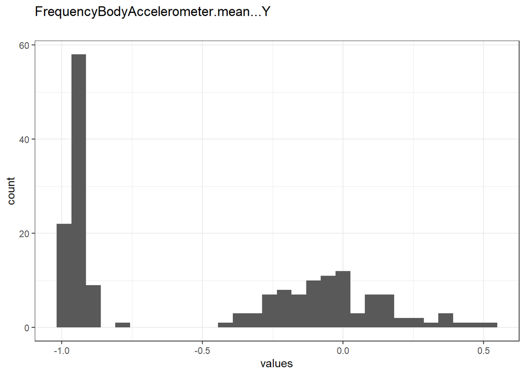

Distribution of values for FrequencyBodyAccelerometer.mean…Y

0 missing values.

#### Summary statistics

| name | data_type | n_missing | complete_rate | min | median | max | mean | sd | hist | label |
| --- | --- | --- | --- | --- | --- | --- | --- | --- | --- | --- |
| FrequencyBodyAccelerometer.mean…Y | numeric | 0 | 1 | -0.99 | -0.59 | 0.52 | -0.4887327 | 0.4806496 | ▇▁▃▃▁ | NA |

### FrequencyBodyAccelerometer.mean…Z

#### Distribution

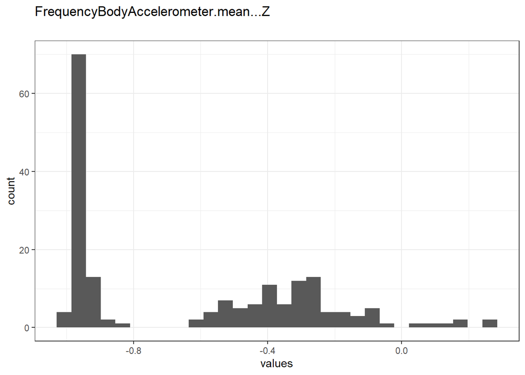

Distribution of values for FrequencyBodyAccelerometer.mean…Z

0 missing values.

#### Summary statistics

| name | data_type | n_missing | complete_rate | min | median | max | mean | sd | hist | label |
| --- | --- | --- | --- | --- | --- | --- | --- | --- | --- | --- |
| FrequencyBodyAccelerometer.mean…Z | numeric | 0 | 1 | -0.99 | -0.72 | 0.28 | -0.6297388 | 0.3556469 | ▇▂▅▁▁ | NA |

### FrequencyBodyAccelerometer.meanFreq…X

#### Distribution

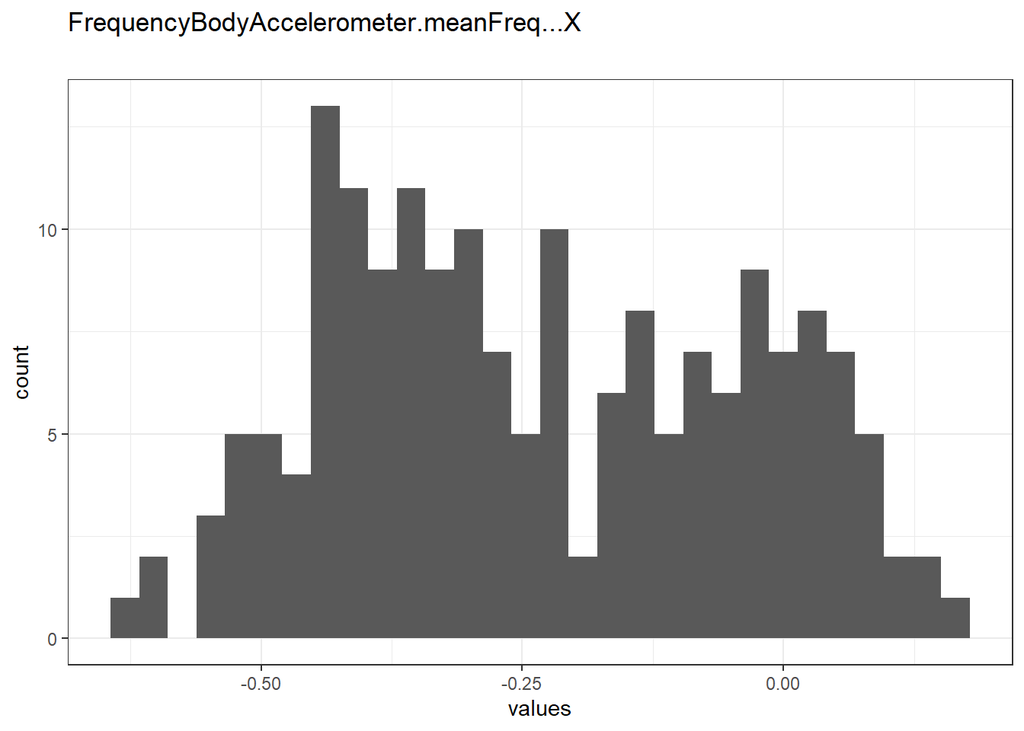

Distribution of values for FrequencyBodyAccelerometer.meanFreq…X

0 missing values.

#### Summary statistics

| name | data_type | n_missing | complete_rate | min | median | max | mean | sd | hist | label |
| --- | --- | --- | --- | --- | --- | --- | --- | --- | --- | --- |
| FrequencyBodyAccelerometer.meanFreq…X | numeric | 0 | 1 | -0.64 | -0.26 | 0.16 | -0.2322661 | 0.1935684 | ▂▇▆▆▃ | NA |

### FrequencyBodyAccelerometer.meanFreq…Y

#### Distribution

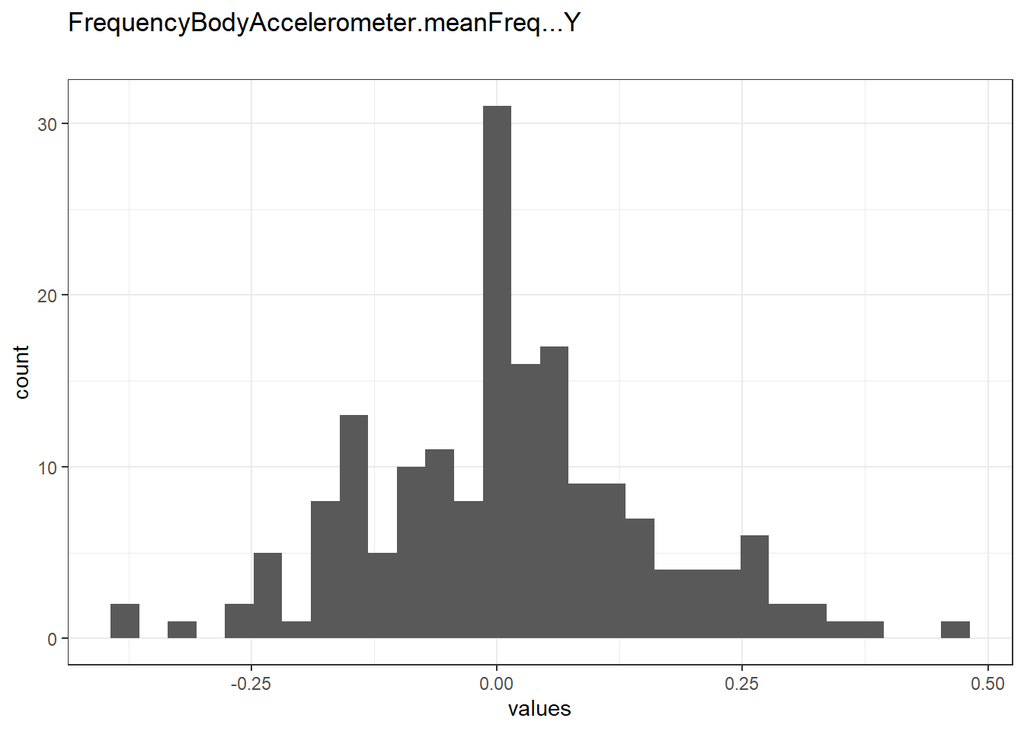

Distribution of values for FrequencyBodyAccelerometer.meanFreq…Y

0 missing values.

#### Summary statistics

| name | data_type | n_missing | complete_rate | min | median | max | mean | sd | hist | label |
| --- | --- | --- | --- | --- | --- | --- | --- | --- | --- | --- |
| FrequencyBodyAccelerometer.meanFreq…Y | numeric | 0 | 1 | -0.38 | 0.0079 | 0.47 | 0.0115289 | 0.1447051 | ▁▅▇▂▁ | NA |

### FrequencyBodyAccelerometer.meanFreq…Z

#### Distribution

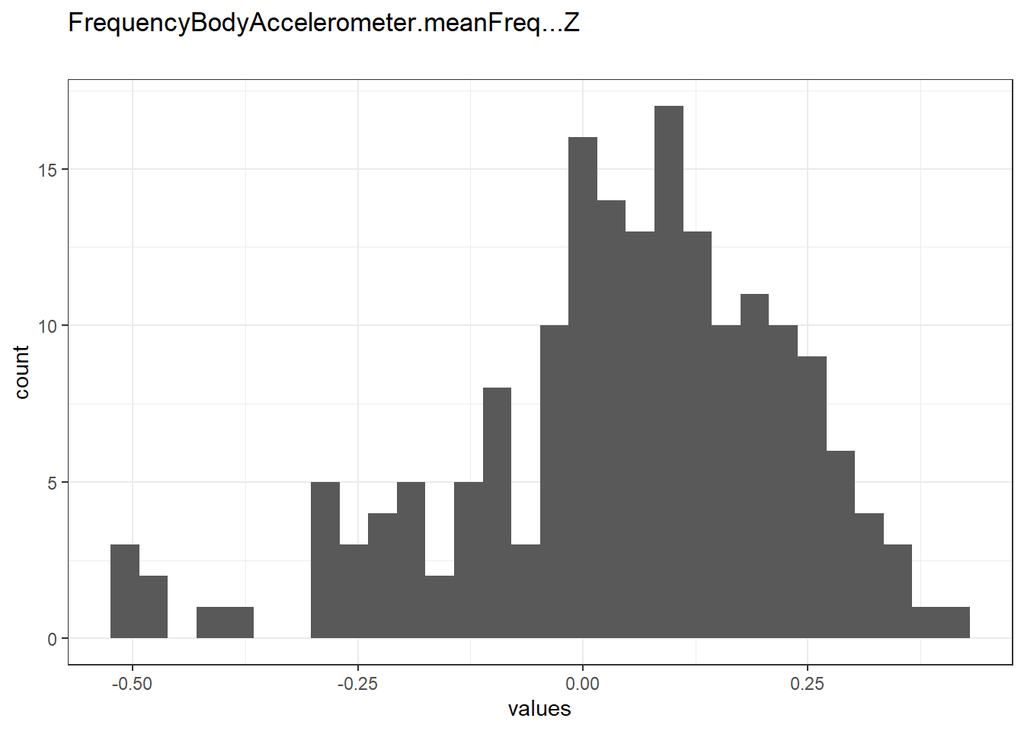

Distribution of values for FrequencyBodyAccelerometer.meanFreq…Z

0 missing values.

#### Summary statistics

| name | data_type | n_missing | complete_rate | min | median | max | mean | sd | hist | label |
| --- | --- | --- | --- | --- | --- | --- | --- | --- | --- | --- |
| FrequencyBodyAccelerometer.meanFreq…Z | numeric | 0 | 1 | -0.52 | 0.066 | 0.4 | 0.0437174 | 0.1850113 | ▁▂▆▇▃ | NA |

### FrequencyBodyAccelerometerJerk.mean…X

#### Distribution

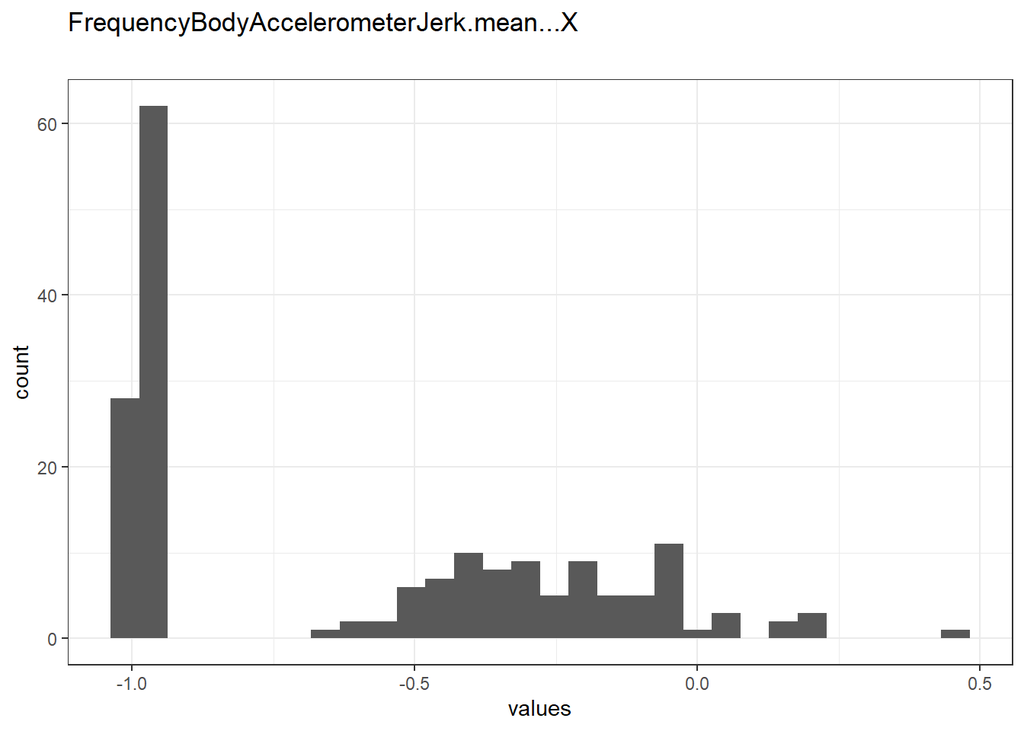

Distribution of values for FrequencyBodyAccelerometerJerk.mean…X

0 missing values.

#### Summary statistics

| name | data_type | n_missing | complete_rate | min | median | max | mean | sd | hist | label |
| --- | --- | --- | --- | --- | --- | --- | --- | --- | --- | --- |
| FrequencyBodyAccelerometerJerk.mean…X | numeric | 0 | 1 | -0.99 | -0.81 | 0.47 | -0.6139282 | 0.3982896 | ▇▂▃▂▁ | NA |

### FrequencyBodyAccelerometerJerk.mean…Y

#### Distribution

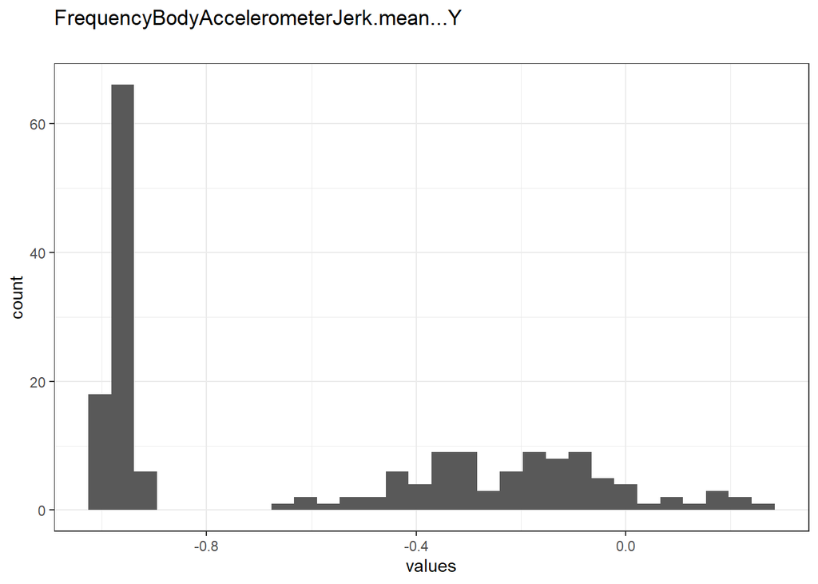

Distribution of values for FrequencyBodyAccelerometerJerk.mean…Y

0 missing values.

#### Summary statistics

| name | data_type | n_missing | complete_rate | min | median | max | mean | sd | hist | label |
| --- | --- | --- | --- | --- | --- | --- | --- | --- | --- | --- |
| FrequencyBodyAccelerometerJerk.mean…Y | numeric | 0 | 1 | -0.99 | -0.78 | 0.28 | -0.5881631 | 0.4077491 | ▇▁▃▃▁ | NA |

### FrequencyBodyAccelerometerJerk.mean…Z

#### Distribution

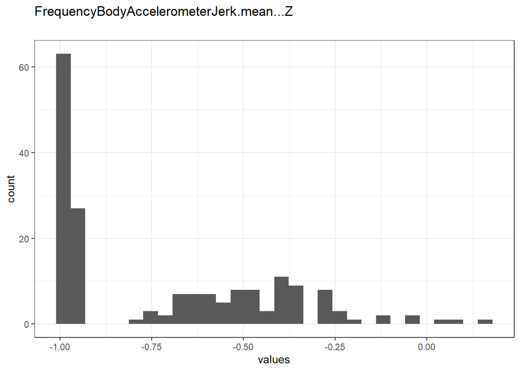

Distribution of values for FrequencyBodyAccelerometerJerk.mean…Z

0 missing values.

#### Summary statistics

| name | data_type | n_missing | complete_rate | min | median | max | mean | sd | hist | label |
| --- | --- | --- | --- | --- | --- | --- | --- | --- | --- | --- |
| FrequencyBodyAccelerometerJerk.mean…Z | numeric | 0 | 1 | -0.99 | -0.87 | 0.16 | -0.7143585 | 0.2970225 | ▇▂▃▁▁ | NA |